# DESeq2 analysis CRS vs anaerobic

The following DESeq analysis uses lessons from https://github.com/hbctraining/DGE_workshop. Here we will be examining the differential expression of CALU-3 cell genes comparing anaerobic_CRS environment to anaerobic environment. # Setup

```r
### Bioconductor Github and CRAN libraries used
library(tidyverse)
```

```r
library(RColorBrewer)
library(DESeq2)
```

```r
library(pheatmap)
library(DEGreport)
library(ggpubr)
```

```r
library(ggrepel)
library(wesanderson)
library(cowplot)
```

```r
theme_set(theme_bw())
```

# Load in data

subread.txt was produces by MSI using the following conditions (copied from the rna-seq report.html provided by UMGC/MSI:

> “The RNA-Seq dataset was analyzed using the reference Human (Homo_sapiens) genome assembly “GRCh38” using annotation from Ensembl release 98. The Ensembl GTF annotation file was filtered to remove annotations for non-protein-coding features. Fastq files were evenly subsampled down to a maximum of 100,000 reads per sample. Quality of data in fastq files was assessed with FastQC. A Hisat2 splicesite file was generated from the GTF file. Hisat2 was used to align reads to a reference genome using the options ‘–dta-cufflinks –rna-strandness RF –known-splicesite-infile /panfs/roc/umgc/tmp/scratch/200226_A00223_0330_BH2WT2DSXY/demultiplex_20200302-13-02-18/Hunter_Project_027/rnaseq/splicesites.txt -x /panfs/roc/groups/3/umii/public/ensembl/Homo_sapiens/GRCh38/hisat2//genome’. Ribosomal content was determined by aligning the first 10,000 R1 reads to the Silva ribosomal database and reporting the percent of reads with alignment. Gene-level raw read counts were generated using featureCounts from the Subread R package using the options ‘-s 2 -B -p -Q 10’. Insert sizes were summarized with Picard."

The metadata file was made to include two columns of interest.  
1) ATMOSPHERE with two levels: Anaerobic and Aerobic, and  
2) TEST which contains the major experimental groups of this analysis.

```r
## Load in data
data <- read.table("../data/subread.txt", header=T, row.names=1)
meta <- read.table("../data/metadata.txt", header=T, row.names=1)
```

```r
# Check that the row names of the metadata equal the column names of the **raw counts** data
all(colnames(data) == rownames(meta))
```

```
[1] TRUE
```

# Create deseq obect

We are using a simple design ~ TEST here.

```r
# Create DESeq2Dataset object
dds <- DESeqDataSetFromMatrix(countData = data, colData = meta, design = ~ TEST)
```

```
some variables in design formula are characters, converting to factors
```

The reference sample group is automatically set by alphabetical order. Set the reference to be anaerobic.

```r
dds$TEST <- relevel(dds$TEST, ref = "anaerobic")
```

# Differential Expression Analysis

## Run DESeq2

```r
# Run DESeq2 differentiol expression analysis
dds <- DESeq(dds)
#  **Optional step** - Output normalized counts to save as a file to access outside RStudio
normalized_counts <- counts(dds, normalized=TRUE)
```

## Fit curve to gene-wise dispersion estimates

The next step in the workflow is to fit a curve to the dispersion estimates for each gene. The idea behind fitting a curve to the data is that different genes will have different scales of biological variability, but, over all genes, there will be a distribution of reasonable estimates of dispersion.

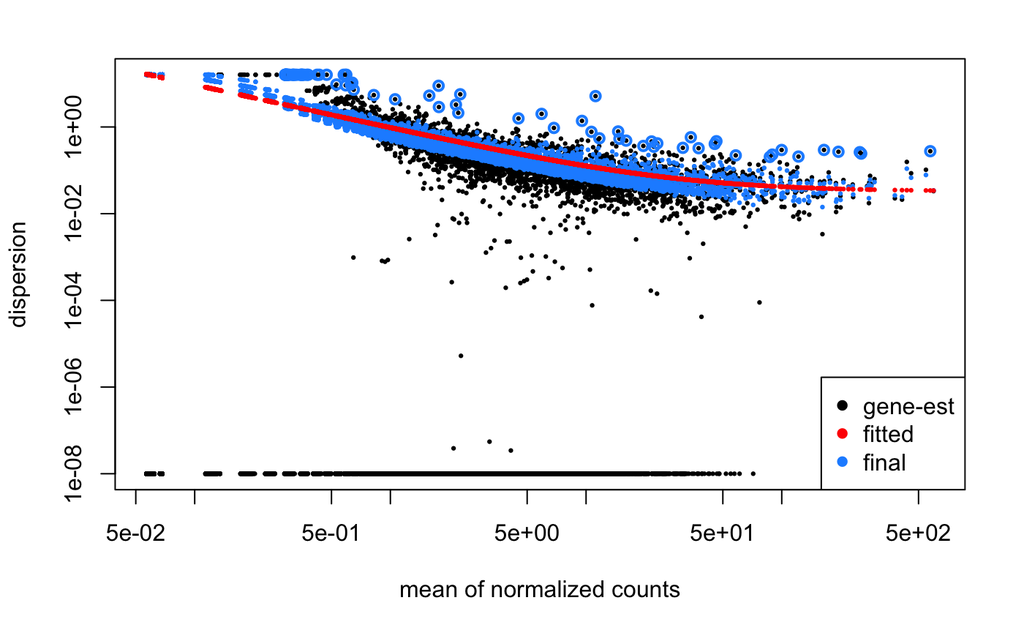

```r
# Plot dispersion estimates
plotDispEsts(dds)
```

Based on this shrinkage curve it looks like our data is a good fit for the model.

Let’s look at the different comparisons that are available to us based on our model:

```r
resultsNames(dds)
```

```
[1] "Intercept"                       "TEST_aerobic_vs_anaerobic"       "TEST_anaerobic_CRS_vs_anaerobic"
```

```r
## Explore the grch38 table loaded by the annotables library
grch38_df <- data.frame(grch38)
```

Use the results function to test DEGs for the CRS vs. anaerobic comparison.

```r
# Output results of Wald test for contrast
contrastCRS <- c("TEST", "anaerobic_CRS", "anaerobic")
resCRS <- results(dds, contrast = contrastCRS)
resCRS <- lfcShrink(dds, contrast = contrastCRS, res=resCRS, type="ashr")
```

```
using 'ashr' for LFC shrinkage. If used in published research, please cite:
    Stephens, M. (2016) False discovery rates: a new deal. Biostatistics, 18:2.
    https://doi.org/10.1093/biostatistics/kxw041
```

```r
summary(resCRS)
```

```
out of 16239 with nonzero total read count
adjusted p-value < 0.1
LFC > 0 (up)       : 20, 0.12%
LFC < 0 (down)     : 5, 0.031%
outliers [1]       : 1, 0.0062%
low counts [2]     : 0, 0%
(mean count < 0)
[1] see 'cooksCutoff' argument of ?results
[2] see 'independentFiltering' argument of ?results
```

Convert results objects into dataframes for plotting and export

```r
# Turn the results object into a data frame
resCRS_df <- data.frame(resCRS) %>%
  rownames_to_column("ensgene") %>%
  left_join(grch38_df, by = "ensgene") # Join annotation data to dataframe
# Save as csv
write_csv(resCRS_df, "../results/DEresults_CRSVSanaerobic.csv")
```

```r
# Set filtering parametes for alpha and lfc
padj.cutoff <- 0.05
lfc.cutoff <- 1
# Subset the significant results
sig_resCRS_p05 <- dplyr::filter(resCRS_df, padj < 0.05 & abs(log2FoldChange) > lfc.cutoff)
sig_resCRS_p01 <- dplyr::filter(resCRS_df, padj < 0.01 & abs(log2FoldChange) > lfc.cutoff)


write_csv(sig_resCRS_p05, "../results/DEresults_sig_crsVSana_p05.csv")
write_csv(sig_resCRS_p01, "../results/DEresults_sig_crsVSana_p01.csv")
```

# MA Plot

### Function: Custom MA Plots

Plot log2FC on the y axis and log2 mean normalized counts on the x-axis.  
Color is based on the adjusted p-value

```r
makeMA_05 <- function(x){
  p <- ggmaplot(x,
                #fc of 2 corresponds to the log2fc of 1 we tested in our hyp. in the results command
                fdr = 0.05,
                fc = 2,
                size = 1,
                palette = alpha(c("#2b74e2","#df5f5b", "gray50"),0.35),
                genenames = as.vector(x$symbol),
                legend = "top",
                top = 20,
                select.top.method   = "fc",
                font.label = c(10, "bold", "black"),
                font.legend = "bold",
                font.main = "bold",
                ggtheme = ggplot2::theme_minimal())
  p
}

makeMA_01 <- function(x){
  p <- ggmaplot(x,
                #fc of 2 corresponds to the log2fc of 1 we tested in our hyp. in the results command
                fdr = 0.01,
                fc = 2,
                size = 1,
                palette = alpha(c("#2b74e2","#df5f5b", "gray50"),0.35),
                genenames = as.vector(x$symbol),
                legend = "top",
                top = 20,
                select.top.method   = "fc",
                font.label = c(10, "bold", "black"),
                font.legend = "bold",
                font.main = "bold",
                ggtheme = ggplot2::theme_minimal())
  p
}
makeMA_001 <- function(x){
  p <- ggmaplot(x,
                #fc of 2 corresponds to the log2fc of 1 we tested in our hyp. in the results command
                fdr = 0.001,
                fc = 2,
                size = 1,
                palette = alpha(c("#2b74e2","#df5f5b", "gray50"),0.35),
                genenames = as.vector(x$symbol),
                legend = "top",
                top = 0,
                select.top.method   = "fc",
               # label.select = c("ICAM1", "SOD2", "TNFAIP2", "CXCL5", "CXCL1", "PI3", "CXCL3", "C3", "CYP24A1", "OAS1", "SDC4"),
                font.label = c(10, "bold", "black"),
                font.legend = "bold",
                font.main = "bold",
                ggtheme = ggplot2::theme_minimal())
  p
}
```

## Plots for CRS vs anaerobic

```r
maPlotCRS_05 <- makeMA_05(resCRS_df) + ggtitle("CRS vs Anaerobic (ref)") +theme(
    legend.text = element_text(size=rel(0.9)),
    legend.title = element_blank(),
    legend.position = "top") +
  guides(colour = guide_legend(override.aes = list(alpha=0.5, size=3))) +
  scale_colour_manual(values = alpha(c("#2b74e2",  "gray60"),0.5), labels = c("Upregulated (10)", "NS"))
```

```
existing scale.
```

```r
maPlotCRS_05
ggsave(plot = maPlotCRS_05, filename = "../figures/crsVSana/maPlotCRS_anaREF_05.pdf", device = "pdf", height = 5, width = 6)
```

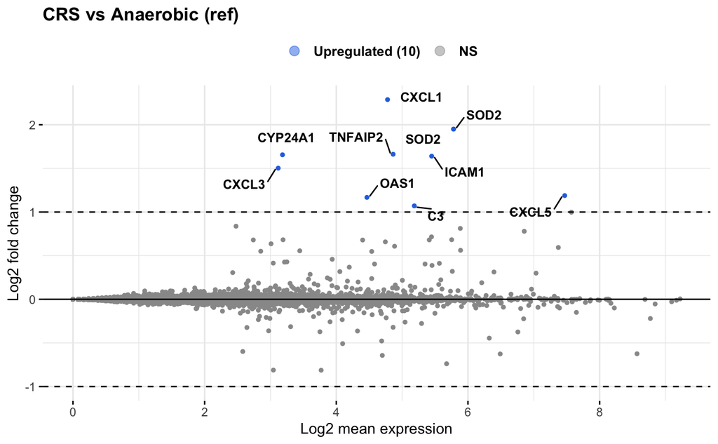

```r
ggsave(plot = maPlotCRS_05, filename = "../figures/crsVSana/maPlotCRS_anaREF_05.png", device = "png", height = 5, width = 6)
```

```r
maPlotCRS_01 <- makeMA_01(resCRS_df) + ggtitle("CRS vs Anaerobic (ref)") +theme(
    legend.text = element_text(size=rel(0.9)),
    legend.title = element_blank(),
    legend.position = "top") +
  guides(colour = guide_legend(override.aes = list(alpha=0.5, size=3))) +
  scale_colour_manual(values = alpha(c("#2b74e2", "gray60"),0.5), labels = c("Upregulated (10)", "NS"))
```

```
existing scale.
```

```r
maPlotCRS_01
ggsave(plot = maPlotCRS_01, filename = "../figures/crsVSana/maPlotCRS_anaREF_01.pdf", device = "pdf", height = 4, width = 6)
```

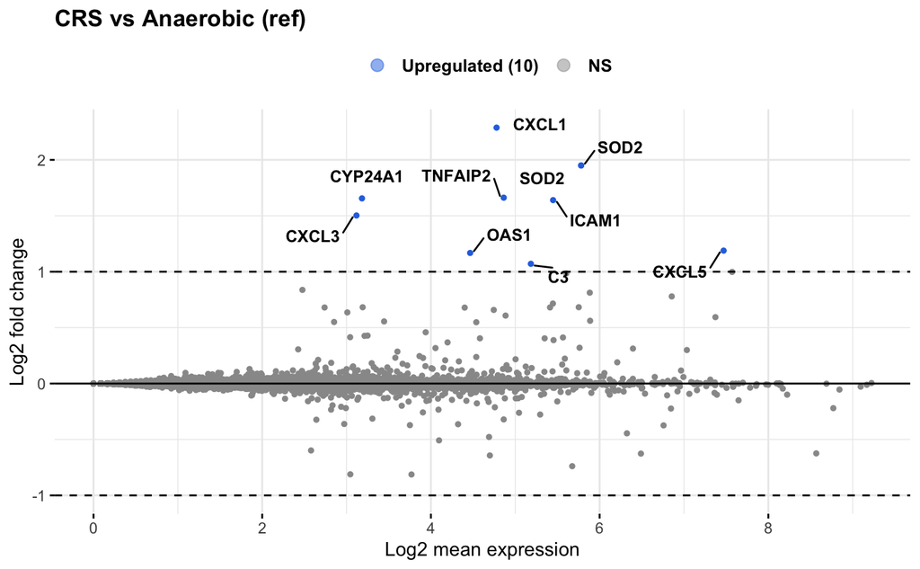

```r
ggsave(plot = maPlotCRS_01, filename = "../figures/crsVSana/maPlotCRS_anaREF_01.png", device = "png", height = 4, width = 6)
```

```r
maPlotCRS_001 <- makeMA_001(resCRS_df) + ggtitle("CRS vs Anaerobic (ref) 001") +theme(
    legend.text = element_text(size=rel(0.9)),
    legend.title = element_blank(),
    legend.position = "top") +
  guides(colour = guide_legend(override.aes = list(alpha=0.5, size=3))) +
  scale_colour_manual(values = alpha(c("#2b74e2", "gray60"),0.5), labels = c("Upregulated (5) (padj<0.001, l2fc > 1)", "NS"))
```

```
existing scale.
```

```r
maPlotCRS_001
ggsave(plot = maPlotCRS_001, filename = "../figures/crsVSana/maPlotCRS_anaREF_001.pdf", device = "pdf", height = 4, width = 6)
```

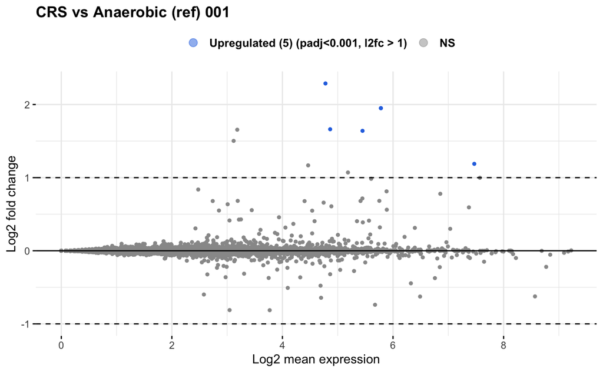

```r
ggsave(plot = maPlotCRS_001, filename = "../figures/crsVSana/maPlotCRS_anaREF_001.png", device = "png", height = 4, width = 6)
```

#Gene count plots Let’s create tibble objects from the meta and normalized_counts data frames before we start plotting. This will enable us to use the tidyverse functionality more easily.

```r
# Create tibbles including row names
DE_meta <- meta %>%
  rownames_to_column(var="SAMPLE_NAME") %>%
  as_tibble()

normalized_counts <- normalized_counts %>%
  data.frame() %>%
  rownames_to_column(var="gene") %>%
  as_tibble()
```

Remove aerobic samples from normalized counts and Meta data

```r
norm_counts_crs <- select(normalized_counts, -starts_with("Sample.Aerobic"))
```

```r
DE_meta_ana <- DE_meta %>% filter(ATMOSPHERE == "anaerobic")
```

Next I want to merge my resCRS_df with normalized so that the symbol is also listed with normalized counts

```r
normalized_resCRS <- inner_join(norm_counts_crs, resCRS_df, by = c("gene" = "ensgene"))
view(normalized_resCRS)
```

Often it is helpful to check the expression of multiple genes of interest at the same time. This often first requires some data wrangling.

We are going to plot the normalized count values for gene groups of interest

```r
#making ploting function (box plot)
GroupGeneCountsBox <- function(x){
  ggplot(x, aes(x = symbol, y = normalized_counts, color = TEST)) +
  geom_boxplot() +
  geom_point(position=position_dodge(w = 0.75)) +
  scale_color_manual(limits = c("anaerobic", "anaerobic_CRS"),
                     values = c("#003F5C","#BC5090")) +
  scale_y_log10() +
        xlab("Genes") +
        ylab("log10 Normalized Counts") +
        ggtitle("") +
        theme_bw() +
    theme(axis.text.x = element_text(angle = 45, hjust = 1)) +
    theme(plot.title = element_text(hjust = 0.5))}
```

Plot the normalized count values for Cytokine Genes

To do this, we first need to list the gene names of interest, then extract normalized count values for those genes.

```r
#list genes of interest
cytogenes <- cytogenes <- c("ENSG00000125538",
"ENSG00000115008",
"ENSG00000136689",
"ENSG00000136244",
"ENSG00000110944",
"ENSG00000169429",
"ENSG00000169245",
"ENSG00000156234",
"ENSG00000189377",
"ENSG00000198223",
"ENSG00000232810",
"ENSG00000163235",
"ENSG00000105329",
"ENSG00000109320",
"ENSG00000090339",
"ENSG00000171855"
)
#normailized counts for those cytokine genes
cyto_crs_norm <- normalized_resCRS %>%
  filter (gene %in% cytogenes)
```

Now that we have the normalized counts for each of the genes for all samples, to plot using ggplot(), we need to gather the counts for all samples into a single column to allow us to give ggplot the one column with the values we want it to plot.

```r
# Gathering the columns to have normalized counts to a single column
gathered_cyto_crs <- cyto_crs_norm %>%
  gather(colnames(cyto_crs_norm)[2:12], key = "SAMPLE_NAME", value = "normalized_counts")

## check the column header in the "gathered" data frame
head(gathered_cyto_crs)
```

| gene | baseMean | log2FoldChange | lfcSE | pvalue | padj | entrez | symbol | chr | start | end | strand | biotype | description | SAMPLE_NAME | normalized_counts |
| --- | --- | --- | --- | --- | --- | --- | --- | --- | --- | --- | --- | --- | --- | --- | --- |
| ENSG00000109320 | 3.4106914 | 0.024268198 | 0.1301203 | 0.22230633 | 1 | 4790 | NFKB1 | 4 | 102501329 | 102617302 | 1 | protein_coding | nuclear factor kappa B subunit 1 [Source:HGNC Symbol;Acc:HGNC:7794] | Sample.Anaerobic | 5.5479629 |
| ENSG00000198223 | 0.1738086 | -0.001074043 | 0.1362940 | 0.88164195 | 1 | 1438 | CSF2RA | X | 1268800 | 1310381 | 1 | protein_coding | colony stimulating factor 2 receptor alpha subunit [Source:HGNC Symbol;Acc:HGNC:2435] | Sample.Anaerobic | 0.9246605 |
| ENSG00000169429 | 34.3049549 | 0.100085037 | 0.2906333 | 0.01143880 | 1 | 3576 | CXCL8 | 4 | 73740506 | 73743716 | 1 | protein_coding | C-X-C motif chemokine ligand 8 [Source:HGNC Symbol;Acc:HGNC:6025] | Sample.Anaerobic | 15.7192284 |
| ENSG00000136689 | 6.9573332 | 0.092628597 | 0.2332818 | 0.02446241 | 1 | 3557 | IL1RN | 2 | 113107214 | 113134016 | 1 | protein_coding | interleukin 1 receptor antagonist [Source:HGNC Symbol;Acc:HGNC:6000] | Sample.Anaerobic | 5.5479629 |
| ENSG00000189377 | 0.3113453 | -0.001892416 | 0.1325403 | 0.83878455 | 1 | 284340 | CXCL17 | 19 | 42428288 | 42443048 | -1 | protein_coding | C-X-C motif chemokine ligand 17 [Source:HGNC Symbol;Acc:HGNC:19232] | Sample.Anaerobic | 0.0000000 |
| ENSG00000125538 | 0.7080463 | 0.020586916 | 0.1557935 | 0.12175193 | 1 | 3553 | IL1B | 2 | 112829751 | 112836903 | -1 | protein_coding | interleukin 1 beta [Source:HGNC Symbol;Acc:HGNC:5992] | Sample.Anaerobic | 0.0000000 |

Now, if we want our counts colored by sample group, then we need to combine the metadata information with the melted normalized counts data into the same data frame for input to ggplot():

```r
gathered_cyto_crs <- inner_join(DE_meta_ana, gathered_cyto_crs, by = c("SAMPLE_NAME" = "SAMPLE_NAME"))
```

The inner_join() will merge 2 data frames with respect to the “SAMPLE_NAME” column, i.e. a column with the same column name in both data frames.

Now that we have a data frame in a format that can be utilised by ggplot easily, let’s plot!

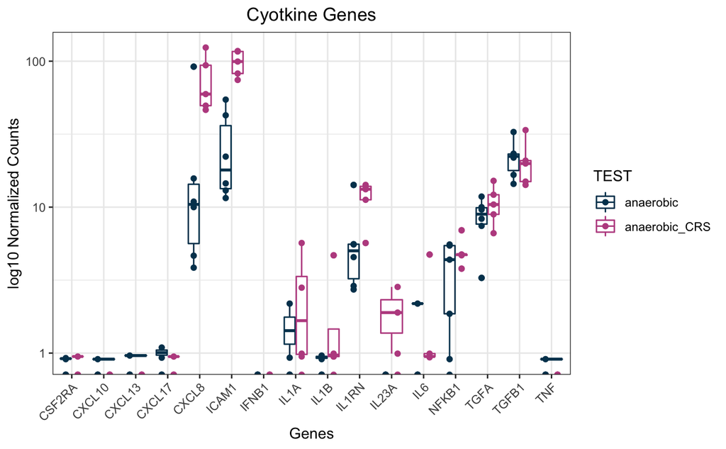

```r
## plot using GroupGeneCount function
cyto_plot <- GroupGeneCountsBox(gathered_cyto_crs) + ggtitle("Cyotkine Genes")
cyto_plot
```

Plot the normalized count values for Mucin Genes

To do this, we first need to list the gene names of interest, then extract normalized count values for those genes.

```r
#list genes of interest
mucingenes <- c("ENSG00000185499",
"ENSG00000145113",
"ENSG00000169894",
"ENSG00000173702",
"ENSG00000184956",
"ENSG00000215182",
"ENSG00000117983"
)
#normailized counts for those mucin genes
mucin_crs_norm <- normalized_resCRS %>%
  filter (gene %in% mucingenes)
```

Now that we have the normalized counts for each of the genes for all samples, to plot using ggplot(), we need to gather the counts for all samples into a single column to allow us to give ggplot the one column with the values we want it to plot.

```r
# Gathering the columns to have normalized counts to a single column
gathered_mucin_crs <- mucin_crs_norm %>%
  gather(colnames(mucin_crs_norm)[2:12], key = "SAMPLE_NAME", value = "normalized_counts")

## check the column header in the "gathered" data frame
head(gathered_mucin_crs)
```

| gene | baseMean | log2FoldChange | lfcSE | pvalue | padj | entrez | symbol | chr | start | end | strand | biotype | description | SAMPLE_NAME | normalized_counts |
| --- | --- | --- | --- | --- | --- | --- | --- | --- | --- | --- | --- | --- | --- | --- | --- |
| ENSG00000215182 | 35.71748276 | 0.002916044 | 0.07212238 | 0.8449305 | 1 | 4586 | MUC5AC | 11 | 1157953 | 1201138 | 1 | protein_coding | mucin 5AC, oligomeric mucus/gel-forming [Source:HGNC Symbol;Acc:HGNC:7515] | Sample.Anaerobic | 50.856327 |
| ENSG00000117983 | 58.00302029 | -0.016965035 | 0.08103635 | 0.3020776 | 1 | 727897 | MUC5B | 11 | 1223066 | 1262172 | 1 | protein_coding | mucin 5B, oligomeric mucus/gel-forming [Source:HGNC Symbol;Acc:HGNC:7516] | Sample.Anaerobic | 61.952253 |
| ENSG00000185499 | 33.70322616 | -0.016200840 | 0.07959809 | 0.3166757 | 1 | 4582 | MUC1 | 1 | 155185824 | 155192916 | -1 | protein_coding | mucin 1, cell surface associated [Source:HGNC Symbol;Acc:HGNC:7508] | Sample.Anaerobic | 24.965833 |
| ENSG00000145113 | 0.05802421 | 0.000000000 | 0.13886427 | 1.0000000 | 1 | 4585 | MUC4 | 3 | 195746765 | 195812277 | -1 | protein_coding | mucin 4, cell surface associated [Source:HGNC Symbol;Acc:HGNC:7514] | Sample.Anaerobic | 0.000000 |
| ENSG00000169894 | 5.11070953 | 0.013827998 | 0.11080044 | 0.4294011 | 1 | 4584 | MUC3A | 7 | 100949555 | 100968346 | 1 | protein_coding | mucin 3A, cell surface associated [Source:HGNC Symbol;Acc:HGNC:7513] | Sample.Anaerobic | 3.698642 |
| ENSG00000173702 | 20.60818823 | 0.017967377 | 0.09443542 | 0.3262624 | 1 | 56667 | MUC13 | 3 | 124905442 | 124953819 | -1 | protein_coding | mucin 13, cell surface associated [Source:HGNC Symbol;Acc:HGNC:7511] | Sample.Anaerobic | 15.719228 |

Now, if we want our counts colored by sample group, then we need to combine the metadata information with the melted normalized counts data into the same data frame for input to ggplot():

```r
gathered_mucin_crs <- inner_join(DE_meta, gathered_mucin_crs, by = c("SAMPLE_NAME" = "SAMPLE_NAME"))
```

The inner_join() will merge 2 data frames with respect to the “SAMPLE_NAME” column, i.e. a column with the same column name in both data frames.

Now that we have a data frame in a format that can be utilised by ggplot easily, let’s plot!

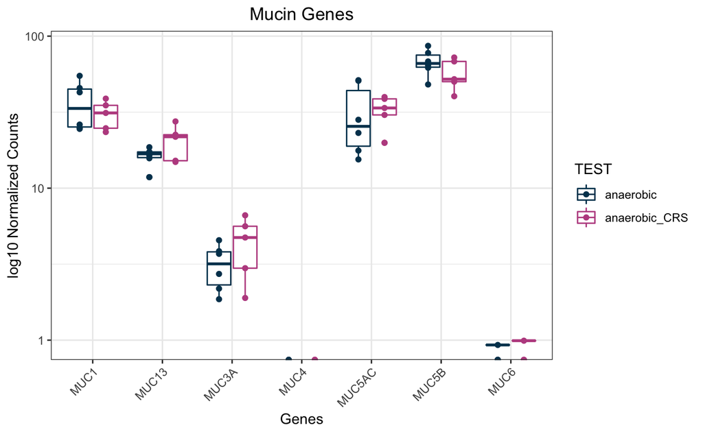

```r
## boxplot using GroupGeneCount function
mucin_plot <- GroupGeneCountsBox(gathered_mucin_crs) + ggtitle("Mucin Genes")
mucin_plot
```

Plot the normalized count values for LDHA

To do this, we first need to list the gene names of interest, then extract normalized count values for those genes.

```r
#list genes of interest
LDHA <- "ENSG00000134333"
#normailized counts for those mucin genes
ldha_crs_norm <- normalized_resCRS %>%
  filter (gene %in% LDHA)
```

Now that we have the normalized counts for each of the genes for all samples, to plot using ggplot(), we need to gather the counts for all samples into a single column to allow us to give ggplot the one column with the values we want it to plot.

```r
# Gathering the columns to have normalized counts to a single column
gathered_ldha_crs <- ldha_crs_norm %>%
  gather(colnames(ldha_crs_norm)[2:12], key = "SAMPLE_NAME", value = "normalized_counts")

## check the column header in the "gathered" data frame
head(gathered_ldha_crs)
```

| gene | baseMean | log2FoldChange | lfcSE | pvalue | padj | entrez | symbol | chr | start | end | strand | biotype | description | SAMPLE_NAME | normalized_counts |
| --- | --- | --- | --- | --- | --- | --- | --- | --- | --- | --- | --- | --- | --- | --- | --- |
| ENSG00000134333 | 219.4127 | -0.03659691 | 0.1048178 | 0.09783523 | 1 | 3939 | LDHA | 11 | 18394388 | 18408425 | 1 | protein_coding | lactate dehydrogenase A [Source:HGNC Symbol;Acc:HGNC:6535] | Sample.Anaerobic | 215.4459 |
| ENSG00000134333 | 219.4127 | -0.03659691 | 0.1048178 | 0.09783523 | 1 | 3939 | LDHA | 11 | 18394388 | 18408425 | 1 | protein_coding | lactate dehydrogenase A [Source:HGNC Symbol;Acc:HGNC:6535] | Sample.Anaerobic.006.A03 | 292.5984 |
| ENSG00000134333 | 219.4127 | -0.03659691 | 0.1048178 | 0.09783523 | 1 | 3939 | LDHA | 11 | 18394388 | 18408425 | 1 | protein_coding | lactate dehydrogenase A [Source:HGNC Symbol;Acc:HGNC:6535] | Sample.Anaerobic.006.A04 | 326.2829 |
| ENSG00000134333 | 219.4127 | -0.03659691 | 0.1048178 | 0.09783523 | 1 | 3939 | LDHA | 11 | 18394388 | 18408425 | 1 | protein_coding | lactate dehydrogenase A [Source:HGNC Symbol;Acc:HGNC:6535] | Sample.Anaerobic.006.A05 | 332.9011 |
| ENSG00000134333 | 219.4127 | -0.03659691 | 0.1048178 | 0.09783523 | 1 | 3939 | LDHA | 11 | 18394388 | 18408425 | 1 | protein_coding | lactate dehydrogenase A [Source:HGNC Symbol;Acc:HGNC:6535] | Sample.Anaerobic.006.A06 | 267.4020 |
| ENSG00000134333 | 219.4127 | -0.03659691 | 0.1048178 | 0.09783523 | 1 | 3939 | LDHA | 11 | 18394388 | 18408425 | 1 | protein_coding | lactate dehydrogenase A [Source:HGNC Symbol;Acc:HGNC:6535] | Sample.Anaerobic.006.A07 | 267.2546 |

Now, if we want our counts colored by sample group, then we need to combine the metadata information with the melted normalized counts data into the same data frame for input to ggplot():

```r
gathered_ldha_crs <- inner_join(DE_meta, gathered_ldha_crs, by = c("SAMPLE_NAME" = "SAMPLE_NAME"))
```

The inner_join() will merge 2 data frames with respect to the “SAMPLE_NAME” column, i.e. a column with the same column name in both data frames.

Now that we have a data frame in a format that can be utilised by ggplot easily, let’s plot!

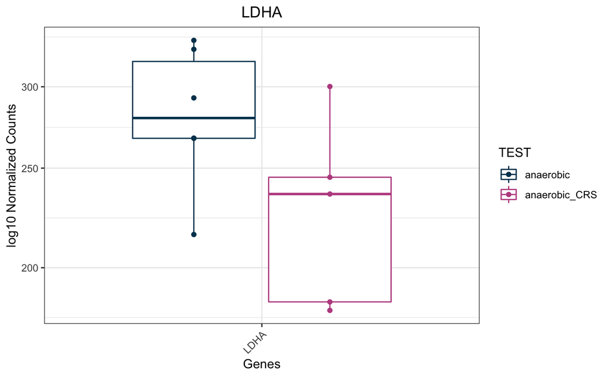

```r
## plot using GroupGeneCount function
ldha_plot <- GroupGeneCountsBox(gathered_ldha_crs) + ggtitle("LDHA")
ldha_plot
```

Plot the normalized count values for HIF1A

To do this, we first need to list the gene names of interest, then extract normalized count values for those genes.

```r
#list genes of interest
HIF1A <- "ENSG00000100644"
#normailized counts for those mucin genes
hif1a_crs_norm <- normalized_resCRS %>%
  filter (gene %in% HIF1A)
```

Now that we have the normalized counts for each of the genes for all samples, to plot using ggplot(), we need to gather the counts for all samples into a single column to allow us to give ggplot the one column with the values we want it to plot.

```r
# Gathering the columns to have normalized counts to a single column
gathered_hif1a_crs <- hif1a_crs_norm %>%
  gather(colnames(hif1a_crs_norm)[2:12], key = "SAMPLE_NAME", value = "normalized_counts")

## check the column header in the "gathered" data frame
head(gathered_hif1a_crs)
```

| gene | baseMean | log2FoldChange | lfcSE | pvalue | padj | entrez | symbol | chr | start | end | strand | biotype | description | SAMPLE_NAME | normalized_counts |
| --- | --- | --- | --- | --- | --- | --- | --- | --- | --- | --- | --- | --- | --- | --- | --- |
| ENSG00000100644 | 20.06069 | 0.003160934 | 0.0651545 | 0.820245 | 1 | 3091 | HIF1A | 14 | 61695513 | 61748259 | 1 | protein_coding | hypoxia inducible factor 1 alpha subunit [Source:HGNC Symbol;Acc:HGNC:4910] | Sample.Anaerobic | 19.417870 |
| ENSG00000100644 | 20.06069 | 0.003160934 | 0.0651545 | 0.820245 | 1 | 3091 | HIF1A | 14 | 61695513 | 61748259 | 1 | protein_coding | hypoxia inducible factor 1 alpha subunit [Source:HGNC Symbol;Acc:HGNC:4910] | Sample.Anaerobic.006.A03 | 25.111054 |
| ENSG00000100644 | 20.06069 | 0.003160934 | 0.0651545 | 0.820245 | 1 | 3091 | HIF1A | 14 | 61695513 | 61748259 | 1 | protein_coding | hypoxia inducible factor 1 alpha subunit [Source:HGNC Symbol;Acc:HGNC:4910] | Sample.Anaerobic.006.A04 | 9.997526 |
| ENSG00000100644 | 20.06069 | 0.003160934 | 0.0651545 | 0.820245 | 1 | 3091 | HIF1A | 14 | 61695513 | 61748259 | 1 | protein_coding | hypoxia inducible factor 1 alpha subunit [Source:HGNC Symbol;Acc:HGNC:4910] | Sample.Anaerobic.006.A05 | 18.597828 |
| ENSG00000100644 | 20.06069 | 0.003160934 | 0.0651545 | 0.820245 | 1 | 3091 | HIF1A | 14 | 61695513 | 61748259 | 1 | protein_coding | hypoxia inducible factor 1 alpha subunit [Source:HGNC Symbol;Acc:HGNC:4910] | Sample.Anaerobic.006.A06 | 15.390040 |
| ENSG00000100644 | 20.06069 | 0.003160934 | 0.0651545 | 0.820245 | 1 | 3091 | HIF1A | 14 | 61695513 | 61748259 | 1 | protein_coding | hypoxia inducible factor 1 alpha subunit [Source:HGNC Symbol;Acc:HGNC:4910] | Sample.Anaerobic.006.A07 | 19.089616 |

Now, if we want our counts colored by sample group, then we need to combine the metadata information with the melted normalized counts data into the same data frame for input to ggplot():

```r
gathered_hif1a_crs <- inner_join(DE_meta, gathered_hif1a_crs, by = c("SAMPLE_NAME" = "SAMPLE_NAME"))
```

The inner_join() will merge 2 data frames with respect to the “SAMPLE_NAME” column, i.e. a column with the same column name in both data frames.

Now that we have a data frame in a format that can be utilised by ggplot easily, let’s plot!

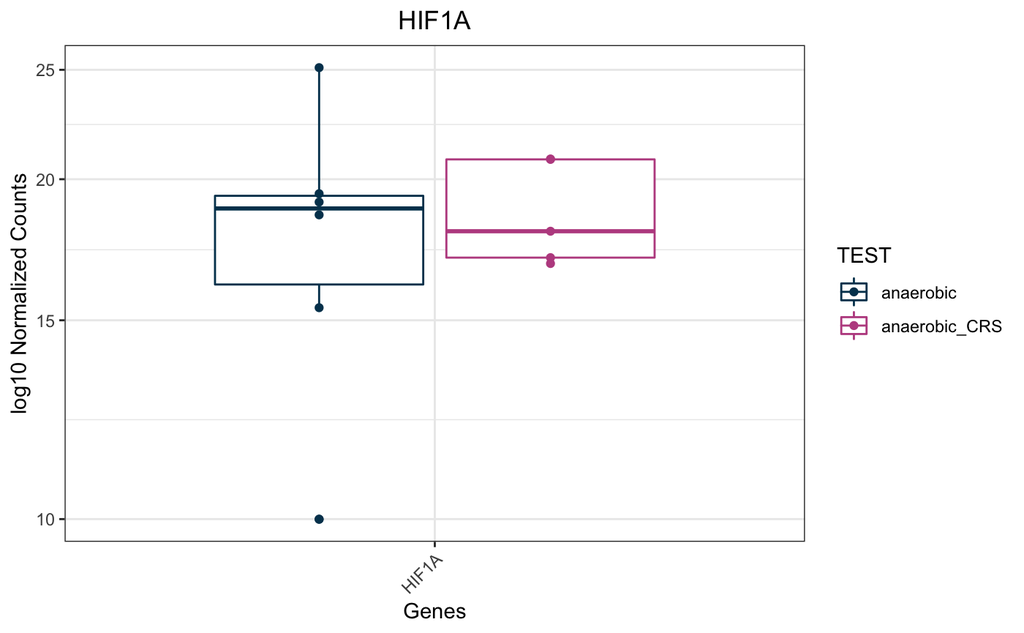

```r
## plot using GroupGeneCount function
HIF1A_plot <- GroupGeneCountsBox(gathered_hif1a_crs) + ggtitle("HIF1A")
HIF1A_plot
```

Plot the normalized count values for chemokines and tnfa1

To do this, we first need to list the gene names of interest, then extract normalized count values for those genes.

```r
#list genes of interest
chemo <- c("ENSG00000163734",
"ENSG00000163735",
"ENSG00000163739",
"ENSG00000109079")
#normailized counts for those mucin genes
chemo_crs_norm <- normalized_resCRS %>%
  filter (gene %in% chemo)
```

Now that we have the normalized counts for each of the genes for all samples, to plot using ggplot(), we need to gather the counts for all samples into a single column to allow us to give ggplot the one column with the values we want it to plot.